# Identifying Environmental Events With Greatest Health and Economic Effects

2016-01-31

## Synopsis

This analysis aims to identify the types of storms which have the biggest economic impact and greatest harm to humans, answering these two questions:

1. Across the United States, which types of events are most harmful with respect to population health?
2. Across the United States, which types of events have the greatest economic consequences?

Excessive heat has caused the most deaths since 1996. Tornadoes the second most and are the leading cause of injury. Flooding has far and away caused the greatest economic damage when crop and property damage is combined.

```r
#normally echo would be off for this
library(dplyr)
library(qdap)
library(stringr)
library(stringdist)
```

```r
library(ggplot2)
source_url = "https://d396qusza40orc.cloudfront.net/repdata%2Fdata%2FStormData.csv.bz2"
local_filename = "StormData.csv.bz2"
evtype_file = "official_evtype.csv"
writeLines(capture.output(sessionInfo()), "sessionInfo.txt")
```

## Data Processing

Analysis is preformed on the U.S. National Oceanic and Atmospheric Administration’s (NOAA) storm database, downloaded on 2016-01-31 from https://d396qusza40orc.cloudfront.net/repdata%2Fdata%2FStormData.csv.bz2. Only data recorded since 1996 was used as prior to this data was only collected for tornadoes, thunderstorms, wind, and hail. Prior to 1956, only tornadoes were documented.

Unzip and read source data. We will also load libraries that we will use later in analysis at this stage.

Since NOAA only began recording all events since 1996, all data for prior years will be dropped. Source: http://www.ncdc.noaa.gov/stormevents/details.jsp?type=eventtype

```r
download.file(source_url, destfile = local_filename)

storm_data_full <- read.csv(bzfile(local_filename), strip.white=TRUE)

cols_to_keep <- c("BGN_DATE",
                        "CROPDMG",
                        "CROPDMGEXP",
                        "PROPDMG",
                        "PROPDMGEXP",
                        "EVTYPE",
                        "INJURIES",
                        "FATALITIES")

storm_data <- storm_data_full[cols_to_keep]

#Pull the year out of the BGN_DATE column.
year_pattern <- "\\d\\d?/\\d\\d?/(\\d\\d\\d\\d).*"
storm_data$YEAR <- as.numeric(gsub(year_pattern, "\\1", storm_data$BGN_DATE))

#since we want to be fair to all the events
storm_data <- storm_data[storm_data$YEAR >= "1996",]
```

A good deal of cleanup is required for the EVTYPE variable. Although only 48 official types have been specified, there are 985 unique values in the source data file. A number of steps have been taken to clean this up, with any values that could not be cleaned mapped to “OTHER”. Each cleanup action in the code below is commented to explain.

A list of official event types was collected by hand from the ￼NATIONAL WEATHER SERVICE INSTRUCTION 10-1605 document published on August 17, 2007. At the time of this report, the document was available here:

http://www.nws.noaa.gov/directives/sym/pd01016005curr.pdf

The official events are saved in official_evtype.csv. This file will be used to map values from EVTYPE to EVTYPE.clean.

```r
evtypes <- read.csv("official_evtype.csv", strip.white = TRUE)
evtypes$EVTYPE.offical <- toupper(evtypes$EVTYPE.offical)

#convert all of EVTYPE to upper case
storm_data$EVTYPE.clean <- str_trim(toupper(storm_data$EVTYPE))
#remove all summary rows, i.e., rows containing the word "SUMMARY" from EVTYPE.clean
storm_data <- storm_data[grep(".*(SUMMARY).*$", storm_data$EVTYPE.clean, invert = TRUE),]
#replace all instances of TSTM with THUNDERSTORM
storm_data$EVTYPE.clean <- gsub("TSTM", "THUNDERSTORM", storm_data$EVTYPE.clean, ignore.case = TRUE)
#cold should always be followed by /wind chill
storm_data$EVTYPE.clean <- gsub("COLD$", "COLD/WIND CHILL", storm_data$EVTYPE.clean, ignore.case = TRUE)
#hurricane should always be followed by /typhon
storm_data$EVTYPE.clean <- gsub("HURRICANE$", "HURRICANE/TYPHOON", storm_data$EVTYPE.clean, ignore.case = TRUE)
#frost should always be followed by /freeze
storm_data$EVTYPE.clean <- gsub("FROST$", "FROST/FREEZE", storm_data$EVTYPE.clean, ignore.case = TRUE)
#get rid of "DAMAGE"
storm_data$EVTYPE.clean <- gsub(" DAMAGE", "", storm_data$EVTYPE.clean, ignore.case = TRUE)
#take out any brackets and their contents
storm_data$EVTYPE.clean <- gsub("\\(.*\\)", "", storm_data$EVTYPE.clean, ignore.case = TRUE)
#if we've managed to add leading and trailing whitesapce, get rid of that
storm_data$EVTYPE.clean <- str_trim(storm_data$EVTYPE.clean)
#take out any trailing Ss. The official does not contain pluralizations
storm_data$EVTYPE.clean <- gsub("S$","", storm_data$EVTYPE.clean, ignore.case = TRUE)
#take out any double spaces
storm_data$EVTYPE.clean <- gsub("  ", " ", storm_data$EVTYPE.clean)
#i think it's possible we introduced whitespace, better trim again
storm_data$EVTYPE.clean <- str_trim(storm_data$EVTYPE.clean)

#perform a string approximation match
match_vector <- amatch(storm_data$EVTYPE.clean , evtypes$EVTYPE.offical)
storm_data$EVTYPE.clean <- evtypes$EVTYPE.offical[match_vector]

#finally, anything that we haven't converted should go from NA to OTHER
storm_data$EVTYPE.clean[is.na(storm_data$EVTYPE.clean)] <- "OTHER"
```

Economic data is stored in two pairs of columns, damage and exponent for property and crops. A lookup table will be used to establish a multiplier which will be used to create a CROP_DAMAGE variable and a PROPERTY_DAMAGE variable in dollars.

```r
#convert the damage and their partner exponent vairables to a cash variable
#we will use the below qdap table to map exponent to a multiplier variable and then to cash

h = 10^2
k = 10^3
th = 10^4
hh = 10^5
m = 10^6
b = 10^9

key <- data.frame(
        c( "H", "h", "2",
           "k", "K", "3",
           "4",
           "5",
           "m", "M", "6",
           "b", "B","9"),
        c( h, h, h,
           k, k, k,
           th,
           hh,
           m, m, m,
           b, b, b)
)

colnames(key) <- c("key", "value")

#perform a simple key match to get a multiplier, then multiply to cash
storm_data$CROP.multiplier <- lookup(key.match = key, storm_data$CROPDMGEXP, missing = 1)
storm_data$CROP_DAMAGE <- storm_data$CROPDMG * storm_data$CROP.multiplier

#repeate for property
storm_data$PROP.multiplier <- lookup(key.match = key, storm_data$PROPDMGEXP, missing = 1)
storm_data$PROPERTY_DAMAGE<- storm_data$PROPDMG * storm_data$PROP.multiplier
```

Here we preform a little cleanup.

```r
# get rid of some of the working columns, just keep what he need going forward
cols_to_keep <- c("YEAR",
                  "EVTYPE.clean",
                  "INJURIES",
                  "FATALITIES",
                  "CROP_DAMAGE",
                  "PROPERTY_DAMAGE")

storm_data <- storm_data[cols_to_keep]
```

The analysis is quite short as the data is now much easier to work with.

```r
storm_data_by_event <- group_by(storm_data, EVTYPE.clean)

harm_summary <- summarise(storm_data_by_event,
                           FATALITIES.total = sum(FATALITIES),
                           INJURIES.total = sum(INJURIES))

#on this scale working in millions of dollars is better than one dollar, although billions or trillions might be more appropriate
damage_summary <- summarise(storm_data_by_event,
                           CROP_DAMAGE.total = sum(CROP_DAMAGE)/1000000,
                           PROPERTY_DAMAGE.total = sum(PROPERTY_DAMAGE)/1000000)

damage_summary$TOTAL <- damage_summary$CROP_DAMAGE.total + damage_summary$PROPERTY_DAMAGE.total
```

## Results

Summary of the worst events for fatalities:

```r
head(arrange(harm_summary, desc(FATALITIES.total)))
```

```
## Source: local data frame [6 x 3]
##
##     EVTYPE.clean FATALITIES.total INJURIES.total
##            (chr)            (dbl)          (dbl)
## 1 EXCESSIVE HEAT             1797           6391
## 2        TORNADO             1511          20667
## 3    FLASH FLOOD              887           1674
## 4      LIGHTNING              651           4141
## 5    RIP CURRENT              542            503
## 6          FLOOD              414           6758
```

Summary of the worst events for injuries:

```r
head(arrange(harm_summary, desc(INJURIES.total)))
```

```
## Source: local data frame [6 x 3]
##
##        EVTYPE.clean FATALITIES.total INJURIES.total
##               (chr)            (dbl)          (dbl)
## 1           TORNADO             1511          20667
## 2             FLOOD              414           6758
## 3    EXCESSIVE HEAT             1797           6391
## 4 THUNDERSTORM WIND              373           5033
## 5         LIGHTNING              651           4141
## 6             OTHER              373           2466
```

Summary of the worst events for economic damage:

```r
head(arrange(damage_summary, desc(TOTAL)))
```

```
## Source: local data frame [6 x 4]
##
##        EVTYPE.clean CROP_DAMAGE.total PROPERTY_DAMAGE.total     TOTAL
##               (chr)             (dbl)                 (dbl)     (dbl)
## 1             FLOOD         4974.7784             143944.83 148919.61
## 2 HURRICANE/TYPHOON         5349.2828              81118.66  86467.94
## 3             OTHER          587.3886              52229.85  52817.24
## 4           TORNADO          283.4250              24616.95  24900.37
## 5              HAIL         2476.0294              14595.14  17071.17
## 6       FLASH FLOOD         1334.9017              15222.25  16557.16
```

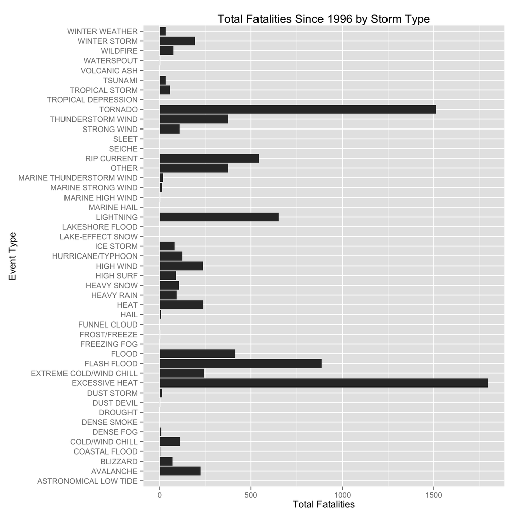

```r
ggplot(harm_summary, aes(factor(EVTYPE.clean), FATALITIES.total))+
        geom_bar(stat="identity") +
        labs(title = "Total Fatalities Since 1996 by Storm Type",
             x = "Event Type",
             y = "Total Fatalities") +
        coord_flip()
```

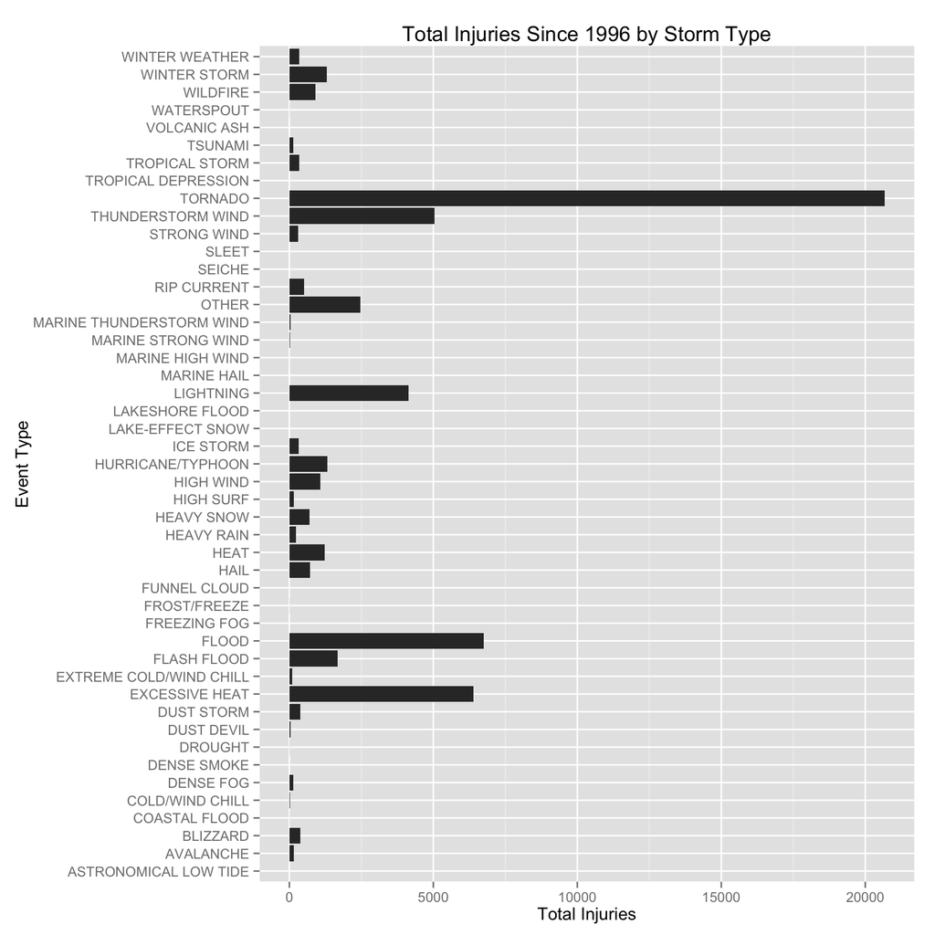

```r
ggplot(harm_summary, aes(x = factor(EVTYPE.clean), y = INJURIES.total))+
        geom_bar(stat="identity") +
        labs(title = "Total Injuries Since 1996 by Storm Type",
             x = "Event Type",
             y = "Total Injuries") +
        coord_flip()
```

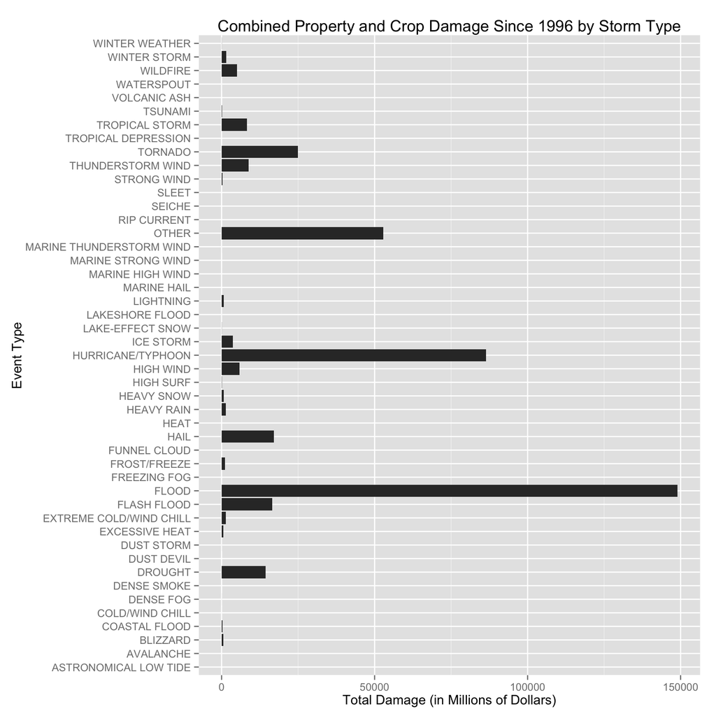

```r
ggplot(damage_summary, aes(x = factor(EVTYPE.clean), y = TOTAL))+
        geom_bar(stat="identity") +
        labs(title = "Combined Property and Crop Damage Since 1996 by Storm Type",
             x = "Event Type",
             y = "Total Damage (in Millions of Dollars)") +
        coord_flip()
```